# Resonance and Filters

1. What does real power mean? How is it different from $Q,~P$ and $S$?

   **Ans:**  
   Real power stands for the power dissipated by the resistor.
2. Explain: >Impedance, like resistance or reactance, is not a phasor quantity representing a time-varying function with a particular phase shift. It is simply an operating tool that is extremely useful in determining the magnitude and angle of quantities in a sinusoidal ac network.
3. Are output voltages the same as voltage drops?

## three phase systems

1. In a Delta system: when we have different line voltages, which one should be used for each branch of the delta system?

   **Ans:**  
   Have a look at the circuit connections. From which wire to which wire are the 2 points of a branch connected? Look for a line voltage that matches such a configuration.
2. Can resonance occur without resistance?

   **Ans:**  
   Theoretically, yes. But practically, no. Resonance circuits are fundamentally studied as RLC circuits
3. Which is correct: $j5~\Omega$ or $5j~\Omega$?

   **Ans:**  
   $j5~\Omega$
4. How to solve:

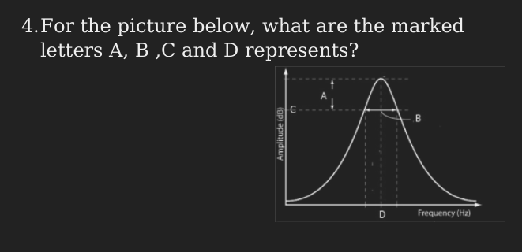